# ACP communes

Gabriel Macé

2024-06-18

# Demandeurs dont le nouvel appareil fonctionne à la buche :

## Test de normalité de Shapiro-Wilk :

Nous allons tester la normalité des distributions, afin d’identifier un éventuel effet “commune”.

Si les comportements des bénéficiaires sont les mêmes dans chaque commune, alors les distributions devraient être normales.

H0 : “La distribution suit une loi normale”.

## ACP :

Je ne garde pas les communes ayant moins de 10 dossiers

Variables utilisées : “Type.Ancien.appareil”, “Usage.ancien.matériel”, “Nouveau.matériel”,“Type.combustible.nouveau.materiel”, “Usage.nouveau.matériel”, “majoration”, “cout_total_TTC, et”Motivation changement appareil”

J’enlève les variables représentant les modalités de type “autre”, “pas de réponse,”NA”, et une des modalités des variables devenues binaires (combustible, majoration)

### Valeurs propres :

```
##        eigenvalue variance.percent cumulative.variance.percent
## Dim.1   6.1143966        35.967039                    35.96704
## Dim.2   1.8308039        10.769435                    46.73647
## Dim.3   1.6077182         9.457166                    56.19364
## Dim.4   1.2567636         7.392727                    63.58637
## Dim.5   1.1286253         6.638972                    70.22534
## Dim.6   1.0060817         5.918128                    76.14347
## Dim.7   0.8999970         5.294100                    81.43757
## Dim.8   0.6905839         4.062258                    85.49983
## Dim.9   0.6700506         3.941474                    89.44130
## Dim.10  0.5679232         3.340725                    92.78202
```

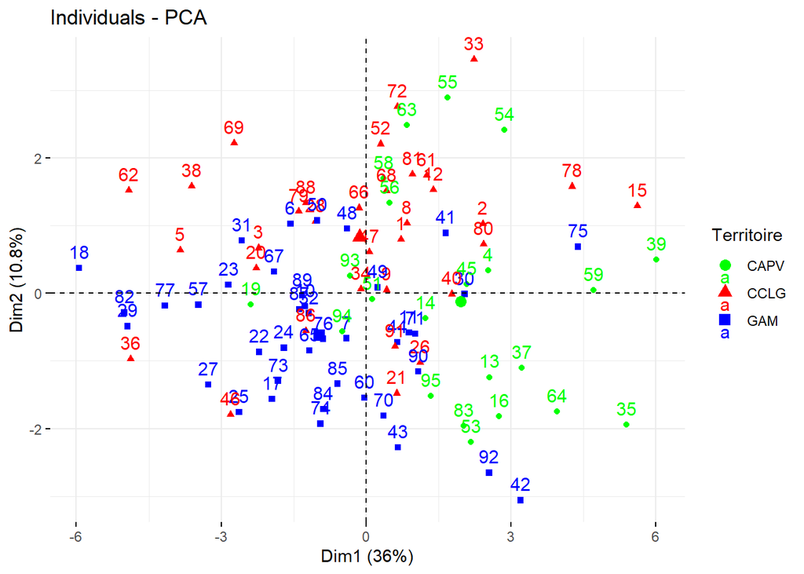

Il semble y avoir une légère séparation par territoire, sur les deux premières dimensions.

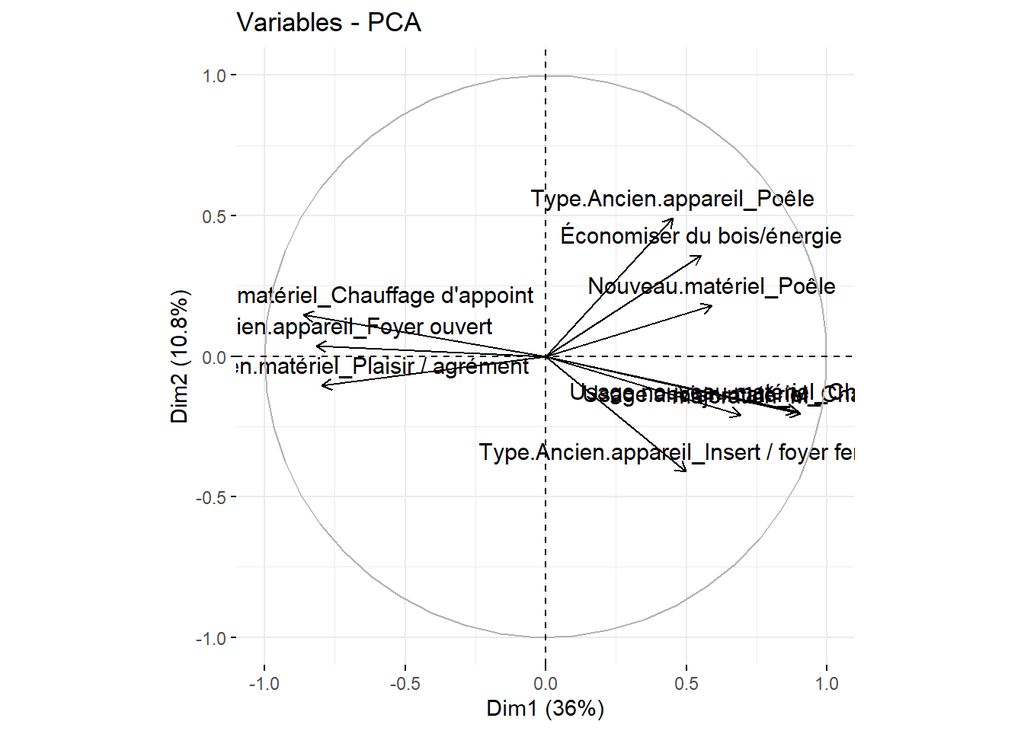

### Contribution et représentation des variables :

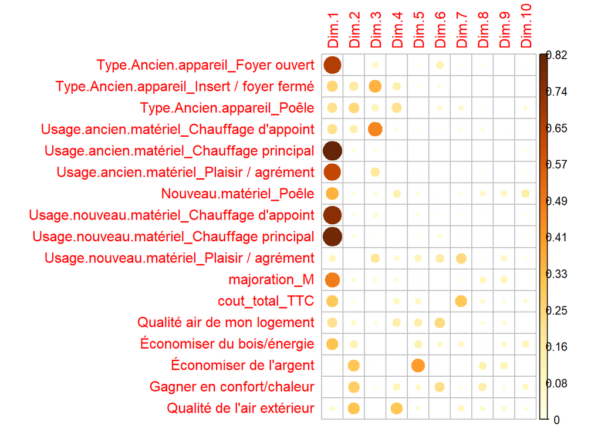

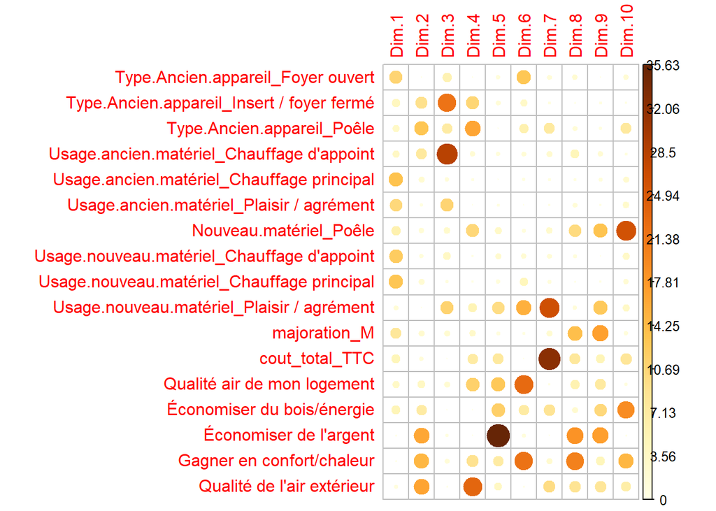

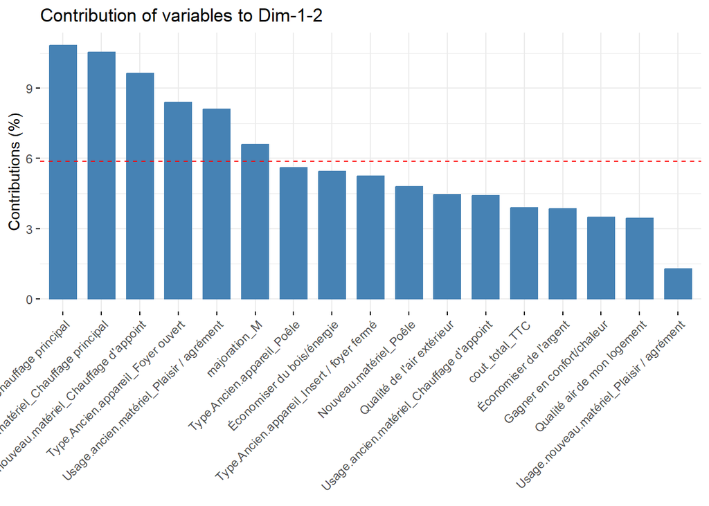

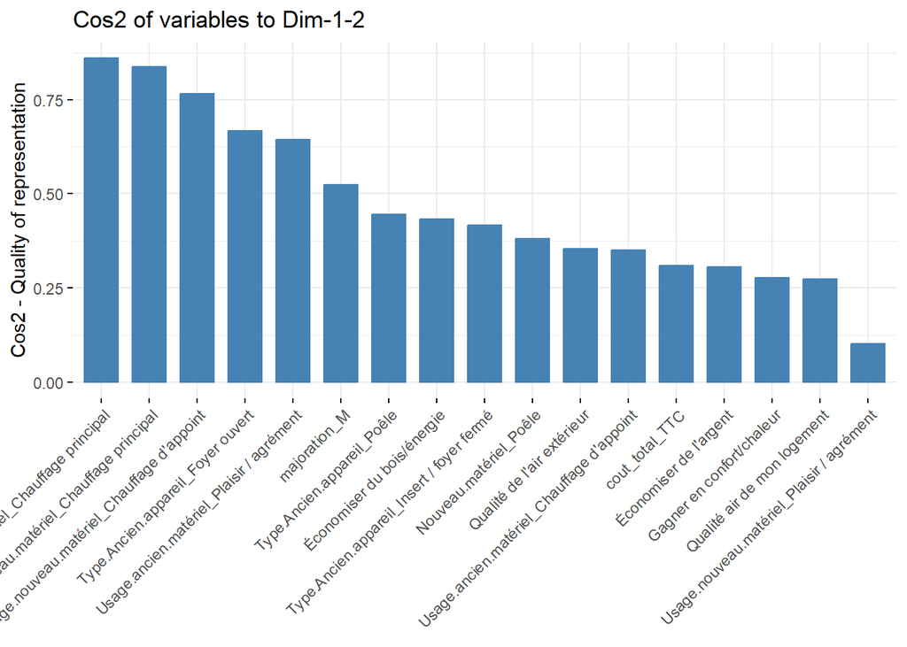

### Type de communes :

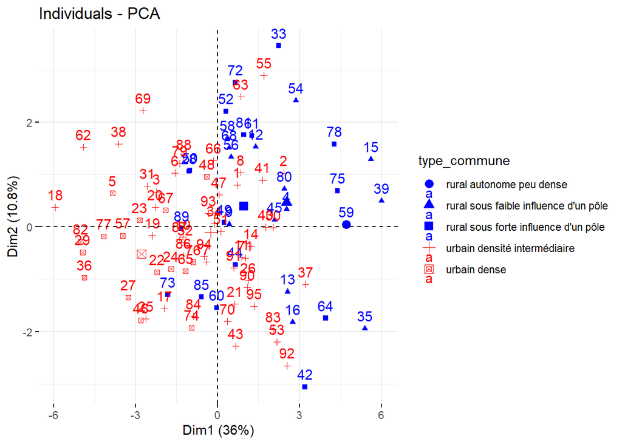

Les deux premières dimensions semblent bien séparer les communes urbaines des rurales

## Clustering :

### Clustering ascendant hiérarchique :

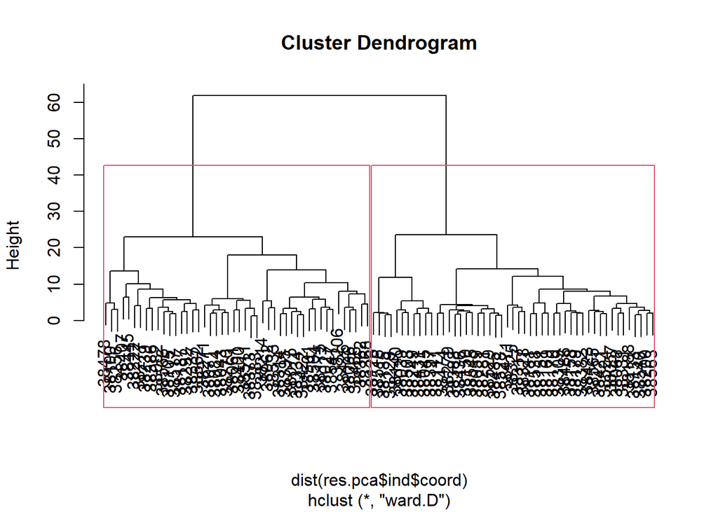

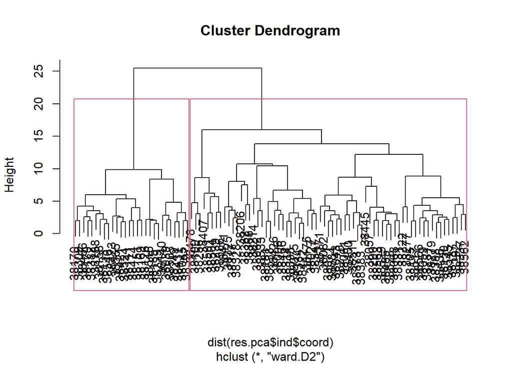

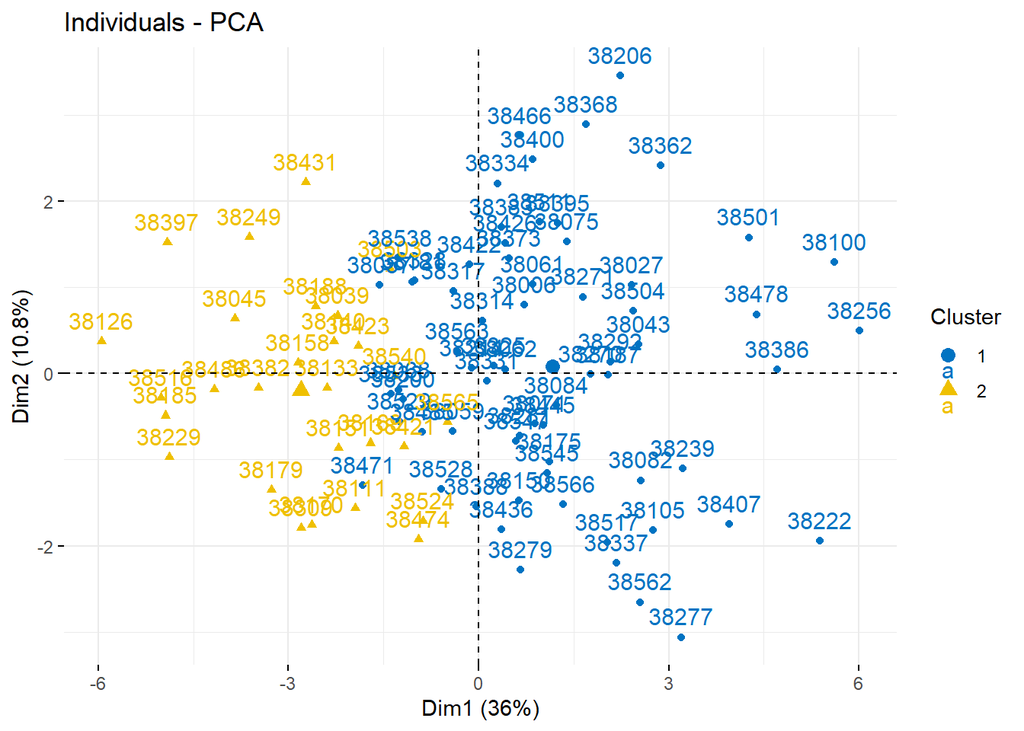

Le dendogramme semble suggérer de créer 2 clusters.

### K-means :

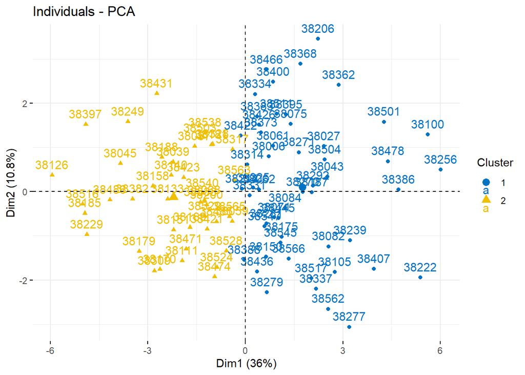

(38472 = Sarcenas, 38080 = Charancieu)

La méthode k-means semble bien séparer les deux groupes, en particulier selon la première dimension.

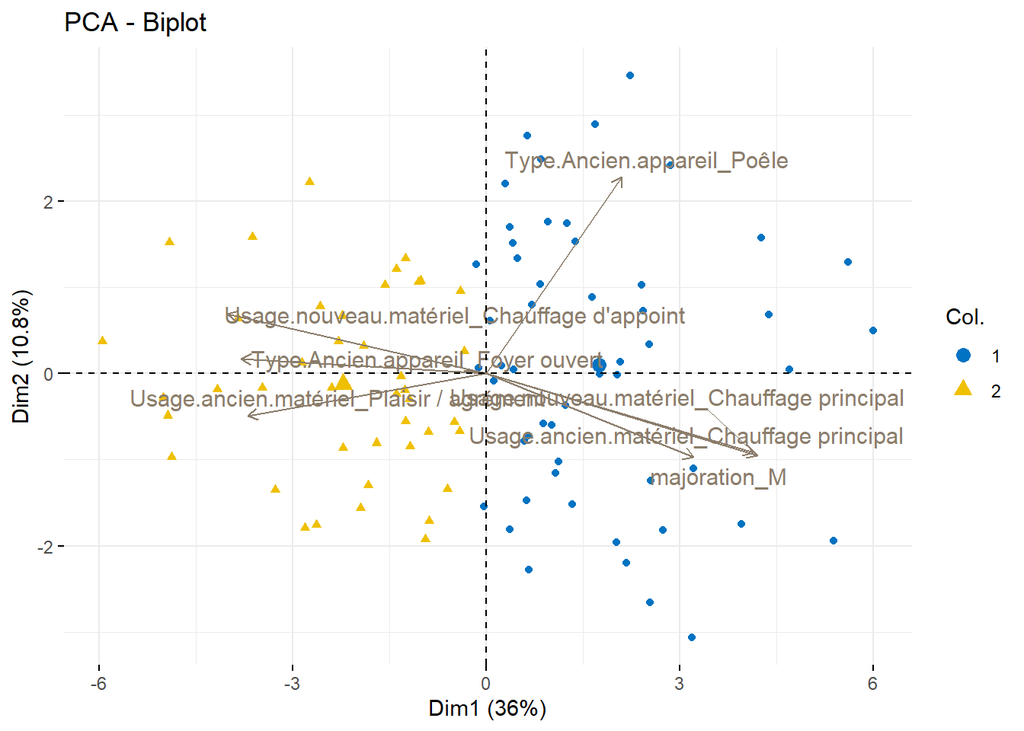

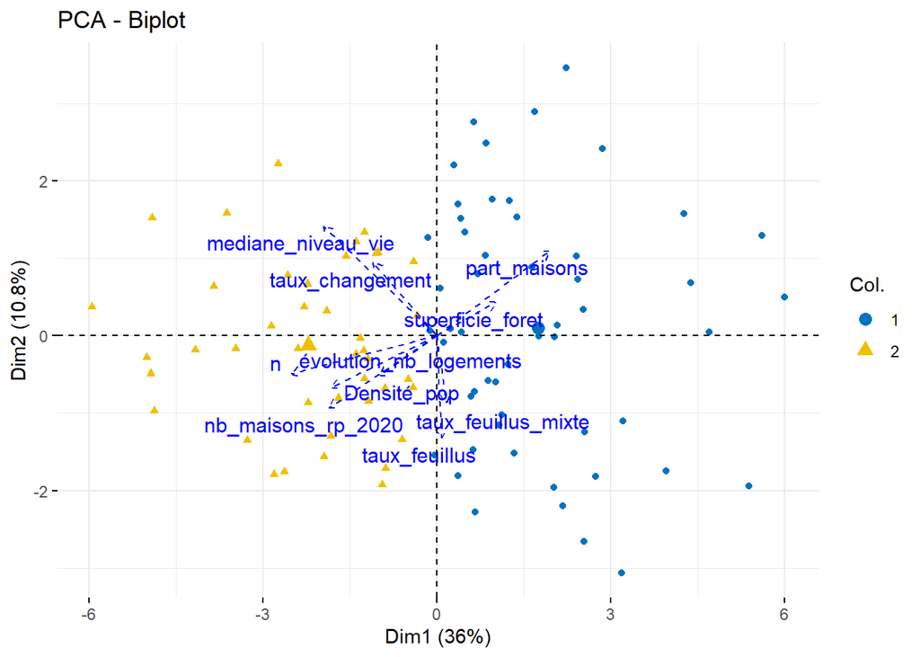

### Carte des clusters :

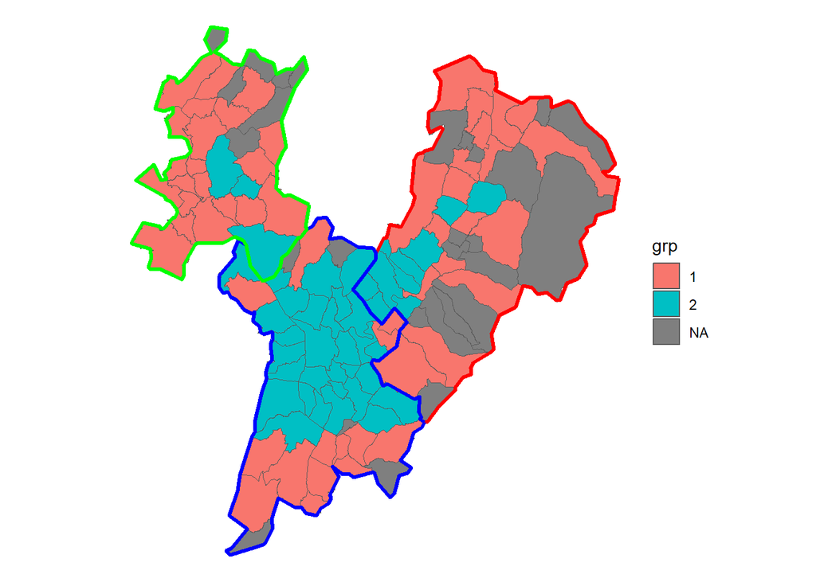

## Carte du type de commune

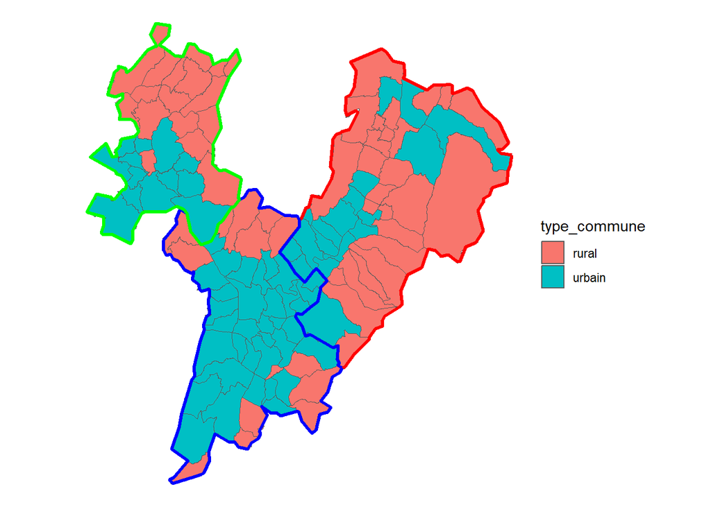

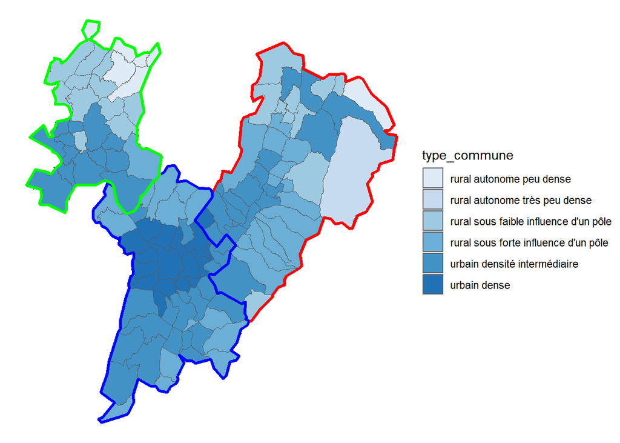

## Lien entre les cluters et les types de communes

```
##
##     rural urbain
##   1    27     26
##   2     5     37
```

Deux groupes : un mixte, un plus urbain

[output not shown]

Trois groupes : un urbain, un rural, un mixte

```
##
##             1    2
##   rural  0.84 0.16
##   urbain 0.41 0.59
```

```
##
##     rural autonome peu dense rural autonome très peu dense
##   1                        1                             0
##   2                        0                             0
##
##     rural sous faible influence d'un pôle rural sous forte influence d'un pôle
##   1                                    14                                   12
##   2                                     0                                    5
##
##     urbain densité intermédiaire urbain dense
##   1                           26            0
##   2                           21           16
```

Groupe 1 = rural sous faible influence d’un pôle, rural sous forte influence d’un pôle, urbain intermédiaire

Groupe 2 = urbain + rurale sous forte influence d’un pôle

Urbain intermédiaire se sépare en deux

```
##
##                                            1    2
##   rural autonome peu dense              1.00 0.00
##   rural autonome très peu dense
##   rural sous faible influence d'un pôle 1.00 0.00
##   rural sous forte influence d'un pôle  0.71 0.29
##   urbain densité intermédiaire          0.55 0.45
##   urbain dense                          0.00 1.00
```

## Comparaison Urbain / rural

## Différences inter-groupes :

### Variables de l’ACP :

Le tableau présente les différences de moyennes entre les deux groupes, pour les variables centrées réduites (cr) ou brutes, ainsi que la proportion de variance de la variable expliquée par la séparation en groupes (X..epl).

Il est ordonné selon la différence de moyennes inter-groupes (pour les variables centrées réduites).

```
##                                            diff_inter_groupes_cr X..epl.
## Qualité.de.l.air.extérieur                                 -0.30    2.22
## Gagner.en.confort.chaleur                                  -0.41    4.10
## Économiser.de.l.argent                                     -0.44    4.84
## Usage.nouveau.matériel_Plaisir...agrément                   0.58    8.43
## Usage.ancien.matériel_Chauffage.d.appoint                   0.68   11.52
## Type.Ancien.appareil_Poêle                                 -0.70   11.92
## Qualité.air.de.mon.logement                                -0.73   13.47
## Économiser.du.bois.énergie                                 -0.84   17.77
## Type.Ancien.appareil_Insert...foyer.fermé                  -0.85   18.02
## cout_total_TTC                                             -0.88   19.38
## Nouveau.matériel_Poêle                                     -0.91   20.81
## majoration_M                                               -0.97   23.76
## Usage.nouveau.matériel_Chauffage.d.appoint                  1.27   40.08
## Type.Ancien.appareil_Foyer.ouvert                           1.32   43.38
## Usage.nouveau.matériel_Chauffage.principal                 -1.36   45.72
## Usage.ancien.matériel_Plaisir...agrément                    1.44   51.81
## Usage.ancien.matériel_Chauffage.principal                  -1.51   56.53
##                                            diff_brute
## Qualité.de.l.air.extérieur                      -0.03
## Gagner.en.confort.chaleur                       -0.04
## Économiser.de.l.argent                          -0.08
## Usage.nouveau.matériel_Plaisir...agrément        0.01
## Usage.ancien.matériel_Chauffage.d.appoint        0.05
## Type.Ancien.appareil_Poêle                      -0.08
## Qualité.air.de.mon.logement                     -0.07
## Économiser.du.bois.énergie                      -0.09
## Type.Ancien.appareil_Insert...foyer.fermé       -0.11
## cout_total_TTC                                -121.76
## Nouveau.matériel_Poêle                          -0.10
## majoration_M                                    -0.08
## Usage.nouveau.matériel_Chauffage.d.appoint       0.17
## Type.Ancien.appareil_Foyer.ouvert                0.18
## Usage.nouveau.matériel_Chauffage.principal      -0.18
## Usage.ancien.matériel_Plaisir...agrément         0.13
## Usage.ancien.matériel_Chauffage.principal       -0.18
```

#### Tests comparaisons d’échantillons :

Tests non paramétrique d’égalité des distributions de Wilcoxon : H0 : “égalité des lois”

Tests paramétriques d’égalité d’espérances, via ANOVA : H0 : “égalité des espérances”

NB : J’ai aussi utilisé le test de Kruskal-Wallis, mais les résultats sont les mêmes que celui de Wilcoxon

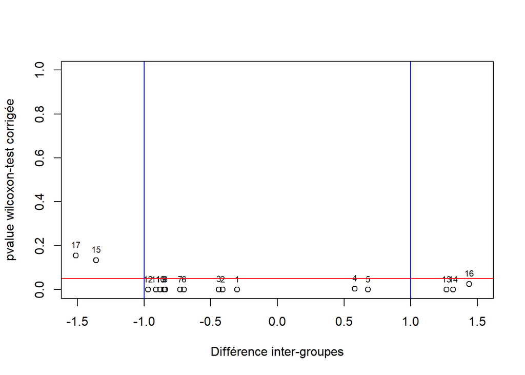

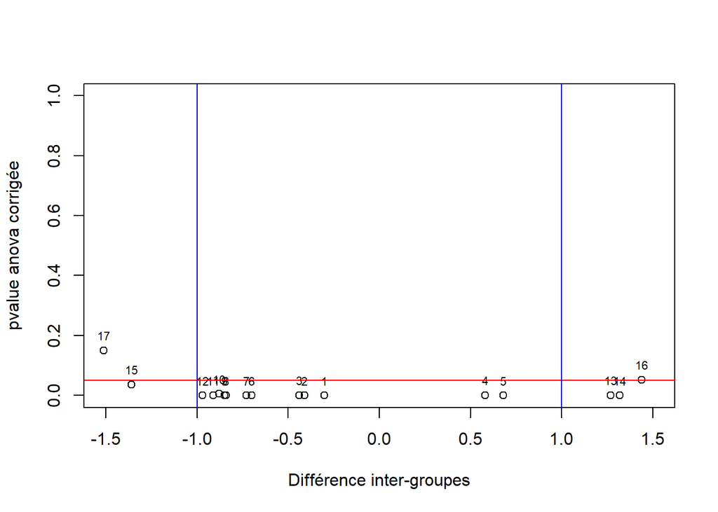

```
##                                     variables Diff_grp pval wilcoxon
## 1                  Qualité.de.l.air.extérieur    -0.30  4.532779e-11
## 2                   Gagner.en.confort.chaleur    -0.41  5.263442e-05
## 3                      Économiser.de.l.argent    -0.44  7.820447e-04
## 4   Usage.nouveau.matériel_Plaisir...agrément     0.58  4.057332e-03
## 5   Usage.ancien.matériel_Chauffage.d.appoint     0.68  1.981240e-13
## 6                  Type.Ancien.appareil_Poêle    -0.70  4.969094e-12
## 7                 Qualité.air.de.mon.logement    -0.73  2.840623e-05
## 8                  Économiser.du.bois.énergie    -0.84  2.772806e-10
## 9   Type.Ancien.appareil_Insert...foyer.fermé    -0.85  9.459299e-12
## 10                             cout_total_TTC    -0.88  1.646540e-04
## 11                     Nouveau.matériel_Poêle    -0.91  7.618895e-06
## 12                               majoration_M    -0.97  6.773458e-06
## 13 Usage.nouveau.matériel_Chauffage.d.appoint     1.27  3.519005e-05
## 14          Type.Ancien.appareil_Foyer.ouvert     1.32  3.519005e-05
```

[output cut: 21 more lines]

Groupe 1 : (mixte urbain / rural)

```
## [1] "Usage.nouveau.matériel_Plaisir...agrément"
## [2] "Usage.ancien.matériel_Chauffage.d.appoint"
## [3] "Usage.nouveau.matériel_Chauffage.d.appoint"
## [4] "Type.Ancien.appareil_Foyer.ouvert"
```

Majorés, chauffage principal, raison changement : plus de modalités / croisement, taux de poêle nouveau ++, ancien : plus d’insert

Groupe 2 : (+ urbain)

```
##  [1] "Qualité.de.l.air.extérieur"
##  [2] "Gagner.en.confort.chaleur"
##  [3] "Économiser.de.l.argent"
##  [4] "Type.Ancien.appareil_Poêle"
##  [5] "Qualité.air.de.mon.logement"
##  [6] "Économiser.du.bois.énergie"
##  [7] "Type.Ancien.appareil_Insert...foyer.fermé"
##  [8] "cout_total_TTC"
##  [9] "Nouveau.matériel_Poêle"
## [10] "majoration_M"
## [11] "Usage.nouveau.matériel_Chauffage.principal"
```

Non majorés, ont un usage moins important de leur appareil (moins dépendants), ancien : + de foyer ouvert

### Variables supplémentaires :

```
##                                 diff_inter_groupes_cr X..epl. diff_brute
## taux_feuillus                                   -0.02    0.02      -0.01
## taux_dossiers_habitant                          -0.03    0.02       0.00
## taux_feuillus_mixte                             -0.11    0.31      -0.02
## objectifs_2022_par_maison                       -0.16    0.63       0.00
## taux_forets                                     -0.25    1.46      -5.07
## taux_changement                                  0.25    1.53       0.01
## évolution_nb_logements                           0.31    2.33       1.36
## superficie_foret                                -0.50    6.14    -298.04
## nb_ménages_fiscaux                               0.50    6.23    3792.91
## mediane_niveau_vie                               0.52    6.80    1868.88
## nb_personnes_menages_fiscaux                     0.53    7.01    7767.15
## objectifs_2022                                   0.61    9.30      50.74
## Densité_pop                                      0.72   12.72     806.61
## Part_résidences_principales_loc                  0.73   13.46       9.18
## n                                                0.88   19.04      31.29
## part_maisons                                    -0.91   20.83     -22.54
```

#### Tests comparaisons d’échantillons :

Tests non paramétrique d’égalité des distributions de Wilcoxon : H0 : “égalité des lois”

Tests paramétriques d’égalité d’espérances, via ANOVA : H0 : “égalité des espérances”

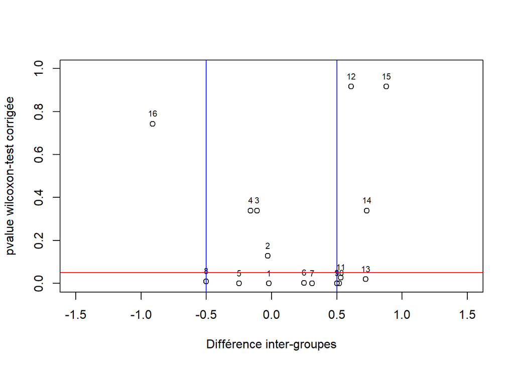

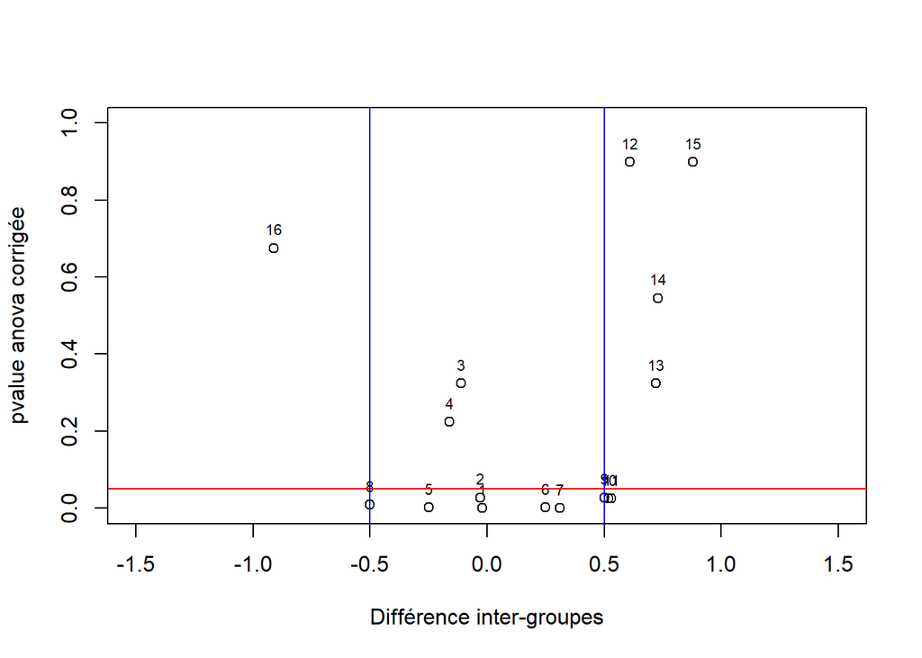

```
##                          variables Diff_grp pval wilcoxon   pval anova index
## 1                    taux_feuillus    -0.02  7.858254e-06 7.861358e-05     1
## 2           taux_dossiers_habitant    -0.03  1.282547e-01 2.743887e-02     2
## 3              taux_feuillus_mixte    -0.11  3.391638e-01 3.241351e-01     3
## 4        objectifs_2022_par_maison    -0.16  3.391638e-01 2.238907e-01     4
## 5                      taux_forets    -0.25  8.396876e-06 1.551028e-03     5
## 6                  taux_changement     0.25  2.277283e-03 1.361426e-03     6
## 7           évolution_nb_logements     0.31  6.009763e-05 5.340132e-05     7
## 8                 superficie_foret    -0.50  9.599335e-03 8.497413e-03     8
## 9               nb_ménages_fiscaux     0.50  1.889391e-04 2.743887e-02     9
## 10              mediane_niveau_vie     0.52  1.889391e-04 2.450135e-02    10
## 11    nb_personnes_menages_fiscaux     0.53  2.727439e-02 2.450135e-02    11
## 12                  objectifs_2022     0.61  9.164462e-01 8.985149e-01    12
## 13                     Densité_pop     0.72  1.903627e-02 3.241351e-01    13
## 14 Part_résidences_principales_loc     0.73  3.391638e-01 5.458947e-01    14
## 15                               n     0.88  9.164462e-01 8.985149e-01    15
## 16                    part_maisons    -0.91  7.431841e-01 6.758117e-01    16
```

Groupe 1 : (mixte urbain / rural)

```
## [1] "taux_changement"              "évolution_nb_logements"
## [3] "nb_ménages_fiscaux"           "mediane_niveau_vie"
## [5] "nb_personnes_menages_fiscaux" "Densité_pop"
```

- forets, taux dossier et objectifs de changement / hab, part de maisons dans les résidences principales Même que acp sur tous, sauf que tous les variables forêts sont plus importantes pour le groupe 1

Groupe 2 : (+ urbain)

```
## [1] "taux_feuillus"    "taux_forets"      "superficie_foret"
```

Clairement des caractéristiques urbaines : plus de pop, meilleur niveau de vie

# Conclusion demandeurs bûches :

Suite à l’acp, nous avons chercher à créer des groupes de communes, le choix de séparer en deux groupes semble là aussi le plus optimal.

Le premier groupe semble être un mixte entre urbain et rural : il est composé à moitié de communes rurales (presque toutes), à moitié de communes urbaines à densité intermédiaire, mais d’aucune urbaine dense. Le deuxième groupe contient principalement des communes urbaines.

Les communes du premier groupe ont en moyenne un taux de prime majorées plus fort (8%), ont un taux plus fort de chauffage principal dans les nouveaux matériels (18%), ont 10 % de plus de pôele dans les noveaux matériels, et remplissent plus de réponses dans les raisons de changement d’appariel, par rapport au deuxième groupe.

Le deuxième groupe a un usage moins important des appareils (appoint, plaisir), avant comme après prime, et a un taux plus fort de foyers ouverts dans les anciens appareils (18%).

Pour les variables supplémentaires, il semble y avoir plus de forêts dans le premier groupe, mais plus de population et une plus forte médiane de niveau de vie dans le deuxième.

Les résultats sont assez ressemblant à ceux sur l’ensemble des demandeurs, sauf qu’ici le premier groupe comprend plus de communes urbaines, et que les variables “forêts” sont toutes plus fortes pour le premier groupe.